# Good fire change over time

Author

Tyler L. McIntosh

Published

October 3, 2024

# Overview

This script analyzes change in good fire over time from 1986 - 2020 (35 years), finding that trends vary by state, but, overall, there does appear to be a closing window for good fire

*Code associated with this workflow is available in the GitHub repo TylerLMcIntosh/a-number-on-good-fire. The code leverages functions from a personal function utilities package, “tlmr”, available on GitHub at TylerLMcIntosh/tlm-r-utility.*

Setup code:

```r
rm(list=ls()) #Ensure empty workspace if running from beginning


if (!requireNamespace("tlmr", quietly = TRUE)) {
  if (!requireNamespace("devtools", quietly = TRUE)) {
    install.packages("devtools")  # Install 'devtools' if it's not available
  }
  devtools::install_github('TylerLMcIntosh/tlm-r-utility', force = TRUE)
}
library(tlmr)
tlmr::install_and_load_packages(c("dplyr",
                                  "rmarkdown",
                                  "purrr",
                                  "here",
                                  "quarto",
                                  "rlang",
                                  "mblm",
                                  "tmap",
                                  "performance",
                                  "gvlma",
                                  "car",
                                  "lmtest",
                                  "olsrr"))

dats <- readr::read_csv(here::here('data', 'derived', paste0("gf_data_combined_states_", 1986, "_", 2020, ".csv")))

annual <- dats |>
  dplyr::relocate(yearPriorForest, .after = totalArea) |>
  dplyr::group_by(year) |>
  dplyr::summarise(dplyr::across(cbiAnyBurned:yearPriorForest, sum)) |>
  dplyr::ungroup() |>
  dplyr::mutate(lowgf_perc_all_burned = 100 * (lowerGoodFire / cbiAnyBurned),
                highgf_perc_all_burned = 100 * (highGoodFire / cbiAnyBurned),
                all_good_fire = highGoodFire + lowerGoodFire,
                allgf_perc_all_burned = 100 * (all_good_fire / cbiAnyBurned))

state_annual <- dats |>
  dplyr::relocate(yearPriorForest, .after = totalArea) |>
  dplyr::group_by(year, NAME) |>
  dplyr::summarise(dplyr::across(cbiAnyBurned:yearPriorForest, sum)) |>
  dplyr::ungroup() |>
  dplyr::mutate(lowgf_perc_all_burned = 100 * (lowerGoodFire / cbiAnyBurned),
                highgf_perc_all_burned = 100 * (highGoodFire / cbiAnyBurned),
                all_good_fire = highGoodFire + lowerGoodFire,
                allgf_perc_all_burned = 100 * (all_good_fire / cbiAnyBurned))
```

# Trends in good fire across the entire western U.S.

First we check basic assumptions about the dataset that we are using, both raw and proportions. We find that there is heteroscedasticity in our data but no autocorrelations or outliers. Thiel-sen estimators will be best to use with this data as they are robust to heteroscedasticity.

Outputs have been hidden to streamline the report.

```r
# create formulas
all_formula <- as.formula("cbiAnyBurned ~ year")
all_gf_formula <- as.formula("all_good_fire ~ year")
lgf_perc_formula <- as.formula("lowgf_perc_all_burned ~ year")
hgf_perc_formula <- as.formula("highgf_perc_all_burned ~ year")
agf_perc_formula <- as.formula("allgf_perc_all_burned ~ year")

formulas <- list(all_formula, all_gf_formula, lgf_perc_formula, hgf_perc_formula, agf_perc_formula)

# A function to perform a set of simple linear model checks
perform_simple_lm_checks <- function(lm, visual = FALSE) {
  perform2 <- gvlma::gvlma(lm)
  summary(perform2)
  if(visual) {print(performance::check_model(lm))}
  print(performance::check_model(lm)$OUTLIERS)
  performance::check_autocorrelation(lm)
}

# Use perform_simple_lm_checks
purrr::walk(.x = formulas, ~ perform_simple_lm_checks(lm(.x, data = annual), visual = FALSE))
```

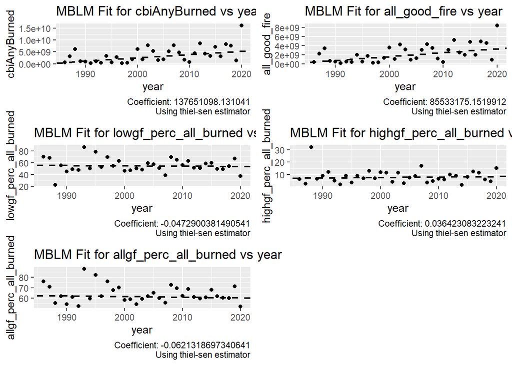

```r
# Raw siegel repeated medians estimators
p1 <- tlmr::mblm_fit_estimator_and_visualize(dats = annual, x = year, y = cbiAnyBurned, repeated = FALSE)

p2 <- tlmr::mblm_fit_estimator_and_visualize(dats = annual, x = year, y = all_good_fire, repeated = FALSE)

# Perc siegel repeated medians estimators
p3 <- tlmr::mblm_fit_estimator_and_visualize(dats = annual, x = year, y = lowgf_perc_all_burned, repeated = FALSE)
p4 <- tlmr::mblm_fit_estimator_and_visualize(dats = annual, x = year, y = highgf_perc_all_burned, repeated = FALSE)
p5 <- tlmr::mblm_fit_estimator_and_visualize(dats = annual, x = year, y = allgf_perc_all_burned, repeated = FALSE)

gridExtra::grid.arrange(p1, p2, p3, p4, p5, nrow = 3, ncol = 2)
```

# How do trends vary by state?

```r
tlmr::mblm_get_coefficients_by_group(dats = state_annual, x = year, y = allgf_perc_all_burned, group = NAME, repeated = FALSE) |>
  dplyr::arrange(dplyr::desc(coefficient))
```

```
# A tibble: 11 × 3
   group      coefficient estimator
   <chr>            <dbl> <chr>
 1 Wyoming         0.270  thiel-sen estimator
 2 Washington      0.0885 thiel-sen estimator
 3 Montana         0.0444 thiel-sen estimator
 4 Arizona         0.0290 thiel-sen estimator
 5 Oregon         -0.0122 thiel-sen estimator
 6 Idaho          -0.198  thiel-sen estimator
 7 California     -0.238  thiel-sen estimator
 8 Colorado       -0.285  thiel-sen estimator
 9 New Mexico     -0.339  thiel-sen estimator
10 Nevada         -0.399  thiel-sen estimator
11 Utah           -0.462  thiel-sen estimator
```

# Geographic visualization

We find that trend coefficients vary greatly by state. To understand these spatial patterns more easily, we can turn the estimator coefficients into geographic visualizations.

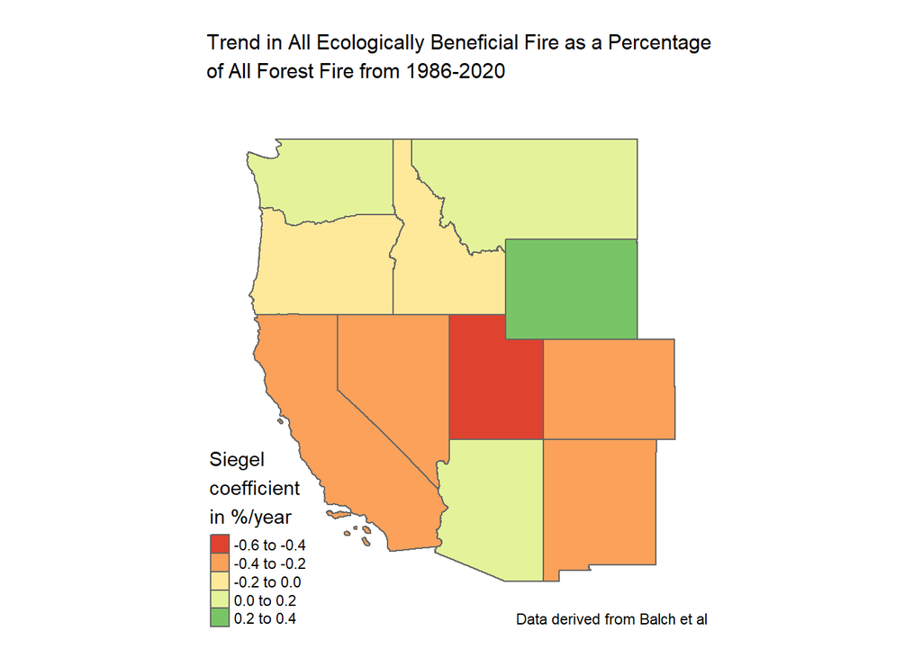

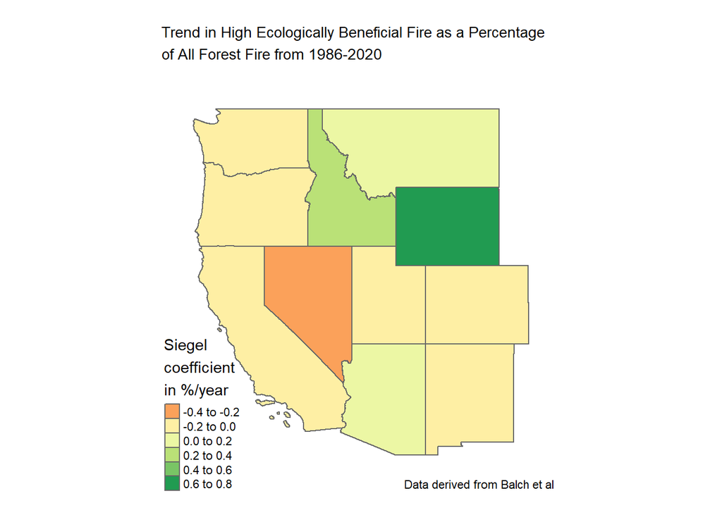

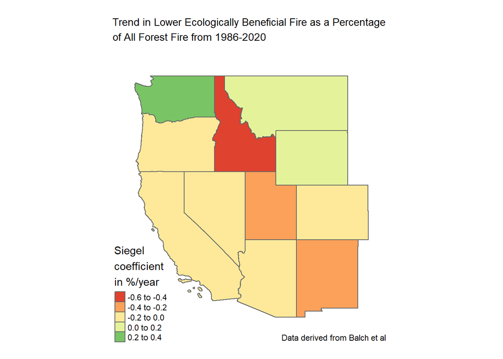

```r
usa <- tigris::states(progress_bar = FALSE)
west <- usa[usa$STUSPS %in% c("WA", "OR", "CA", "ID", "MT", "WY", "NV", "AZ", "CO", "NM", "UT"),]

west_allgf_perc_all_burned <- west |>
  dplyr::left_join(tlmr::mblm_get_coefficients_by_group(dats = state_annual, x = year, y = allgf_perc_all_burned, group = NAME, repeated = FALSE),
                   by = dplyr::join_by(NAME == group))
west_highgf_perc_all_burned <- west |>
  dplyr::left_join(tlmr::mblm_get_coefficients_by_group(dats = state_annual, x = year, y = highgf_perc_all_burned, group = NAME, repeated = FALSE),
                   by = dplyr::join_by(NAME == group))
west_lowgf_perc_all_burned <- west |>
  dplyr::left_join(tlmr::mblm_get_coefficients_by_group(dats = state_annual, x = year, y = lowgf_perc_all_burned, group = NAME, repeated = FALSE),
                   by = dplyr::join_by(NAME == group))

create_west_graphic <- function(dats, title) {
  g <- tmap::tm_shape(dats) +
        tm_polygons("coefficient",
                    midpoint = 0,
                    title = "Siegel \ncoefficient \nin %/year") +
        tm_layout(title = title,
                  inner.margins = c(0.1, 0.1, 0.2, 0.1),
                  frame = FALSE,
                  legend.position = c("left", "bottom")) +
        tm_credits("Data derived from Balch et al")
  return(g)
}

viz_all_gf <- create_west_graphic(west_allgf_perc_all_burned, "Trend in All Ecologically Beneficial Fire as a Percentage \nof All Forest Fire from 1986-2020")
viz_all_gf
create_west_graphic(west_highgf_perc_all_burned, "Trend in High Ecologically Beneficial Fire as a Percentage \nof All Forest Fire from 1986-2020")
create_west_graphic(west_lowgf_perc_all_burned, "Trend in Lower Ecologically Beneficial Fire as a Percentage \nof All Forest Fire from 1986-2020")
```

# Takeaways

We do, indeed, see that there may be a closing window for good fire across the western U.S.

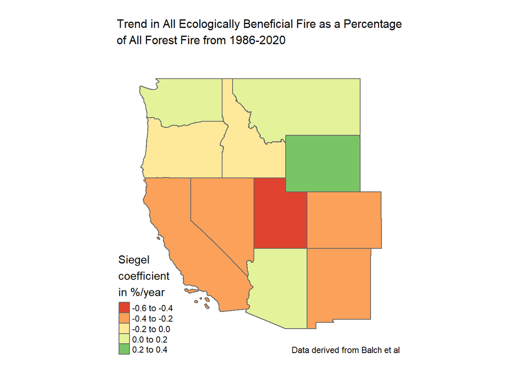

```r
viz_all_gf
```

When considering all good fire, a number of our driest states have seen decreases over time in the amount of good fire when compared to the total forested area burning. Only 4 states (WA, MT, WY, AZ) have seen increasing trends in good fire as a percentage of total area burned over time.

Although changes on the scale of -0.3% / year seem small, over the course of the 35 years combined, this small change adds up to approximately a change of 10 percentage points.

Total percentage point changes over the 35 years for each state are below (rounded to nearest integer)

```r
tlmr::mblm_get_coefficients_by_group(dats = state_annual, x = year, y = allgf_perc_all_burned, group = NAME, repeated = FALSE) |>
  dplyr::arrange(dplyr::desc(coefficient)) |>
  dplyr::mutate(totalPercentagePointChange = round(35 * coefficient)) |>
  dplyr::select(group, totalPercentagePointChange)
```

```
# A tibble: 11 × 2
   group      totalPercentagePointChange
   <chr>                           <dbl>
 1 Wyoming                             9
 2 Washington                          3
 3 Montana                             2
 4 Arizona                             1
 5 Oregon                              0
 6 Idaho                              -7
 7 California                         -8
 8 Colorado                          -10
 9 New Mexico                        -12
10 Nevada                            -14
11 Utah                              -16
```